# **Predictive Modeling of Visa Application Outcomes**

# **Machine Learning: Bagging (Random Forest, Decision Tree), Boosting (AdaBoost, GradientBoost, XGBoost)**

### **+ SMOTE/UnderSampler + CrossValidator/StratifiedKFold/RandomizedSearch**

**Keys**: #Bagging #BaggingClassifier #RandomForest #Boosting #Adaboost #GradientBoost #XGBoost #SMOTE #RandomUnderSampler #CrossValidator #StratifiedKFold #RandomizedSearch #F1-Score

### **Josue Quiros Batista**

[figure not shown]

- Overview of the Dataset
- Exploratory Data Analysis (EDA)
- Univariate Analysis
- Bivariate Analysis
- Data Pre-processing
- Feature Engineering
- Data Preparation for modeling
- Model Evaluation Criterion
- Model building with original data
- Model Building with oversampled data
- Model Building with undersampled data
- Hyperparameter Tuning
- Model performance comparison

## **Problem Statement**

### **Context**

Business communities in the United States are facing high demand for human resources, but one of the constant challenges is identifying and attracting the right talent, which is perhaps the most important element in remaining competitive. Companies in the United States look for hard-working, talented, and qualified individuals both locally as well as abroad.

The Immigration and Nationality Act (INA) of the US permits foreign workers to come to the United States to work on either a temporary or permanent basis. The act also protects US workers against adverse impacts on their wages or working conditions by ensuring US employers' compliance with statutory requirements when they hire foreign workers to fill workforce shortages. The immigration programs are administered by the Office of Foreign Labor Certification (OFLC).

OFLC processes job certification applications for employers seeking to bring foreign workers into the United States and grants certifications in those cases where employers can demonstrate that there are not sufficient US workers available to perform the work at wages that meet or exceed the wage paid for the occupation in the area of intended employment.

### **Objective**:

In FY 2016, the OFLC processed 775,979 employer applications for 1,699,957 positions for temporary and permanent labor certifications. This was a nine percent increase in the overall number of processed applications from the previous year. The process of reviewing every case is becoming a tedious task as the number of applicants is increasing every year.

The increasing number of applicants every year calls for a Machine Learning based solution that can help in shortlisting the candidates having higher chances of VISA approval. OFLC has hired the firm EasyVisa for data-driven solutions. You as a data scientist at EasyVisa have to analyze the data provided and, with the help of a classification model:

- Facilitate the process of visa approvals.
- Recommend a suitable profile for the applicants for whom the visa should be certified or denied based on the drivers that significantly influence the case status.

## **Actionable Insights and Business Recommendations derived from this model**

**Key Takeaways - Shortlisting Candidates with Higher Chances of Visa Approval**

These attributes have a more significant impact if:

- Applicants possessing just a high school diploma have a higher rate of denials.
- Prior work experience benefits the applicant to get its visa approved (the approval rate for the 14,802 applicants with work experience is 74.47%. Whereas, the approval rate for those without prior experience is 56.13%)
- Master's Degree and Doctorate Degree holders exhibit a greater likelihood of approval (78.63% acceptance rate). Similarly, of the 2,192 Doctoral degree holders who applied, 1,912 were approved, representing an 87.23% acceptance rate, while the remaining 12.77% were denied.
- Applicants from Europe exhibit a greater likelihood of approval.
- Northeast, South and West regions exhibit high demand for foreign workers.

**Recommend a suitable profile for the applicants for whom the visa should be certified or denied based on the drivers that significantly influence the case status.**

**Strong profile for visa approval**

- Holds a university degree. Even stronger if possessing a Master's or Doctorate degree.
- Has work experience.
- Comes from a European country.
- The intented work region is: Northeast, South, or West.

**Weak Profile for Visa Approval**

- Possesses only a high school diploma.
- Has no work experience.
- Comes from a South American country.

```python
_data = r"/content/EasyVisa.csv"
#_data = r"G:\Mi unidad\Documentos\Data Science\"
_data_original = pd.read_csv(_data)
_data_copy = _data_original.copy()
```

## **Overview of the Dataset**

```python
# First 5 rows of the dataset
_data_copy.head()
```

|  | case_id | continent | education_of_employee | has_job_experience | requires_job_training | no_of_employees | yr_of_estab | region_of_employment | prevailing_wage | unit_of_wage | full_time_position | case_status |
| --- | --- | --- | --- | --- | --- | --- | --- | --- | --- | --- | --- | --- |
| 0 | EZYV01 | Asia | High School | N | N | 14513 | 2007 | West | 592.2029 | Hour | Y | Denied |
| 1 | EZYV02 | Asia | Master's | Y | N | 2412 | 2002 | Northeast | 83425.6500 | Year | Y | Certified |
| 2 | EZYV03 | Asia | Bachelor's | N | Y | 44444 | 2008 | West | 122996.8600 | Year | Y | Denied |
| 3 | EZYV04 | Asia | Bachelor's | N | N | 98 | 1897 | West | 83434.0300 | Year | Y | Denied |
| 4 | EZYV05 | Africa | Master's | Y | N | 1082 | 2005 | South | 149907.3900 | Year | Y | Certified |

#### Understand the shape of the dataset

```python
print(_data_copy.shape)
print("There are", _data_copy.shape[0], 'rows and', _data_copy.shape[1], "columns.")
```

```
(25480, 12)
There are 25480 rows and 12 columns.
```

```python
_data_copy.info()
```

```
<class 'pandas.core.frame.DataFrame'>
RangeIndex: 25480 entries, 0 to 25479
Data columns (total 12 columns):
 #   Column                 Non-Null Count  Dtype
---  ------                 --------------  -----
 0   case_id                25480 non-null  object
 1   continent              25480 non-null  object
 2   education_of_employee  25480 non-null  object
 3   has_job_experience     25480 non-null  object
 4   requires_job_training  25480 non-null  object
 5   no_of_employees        25480 non-null  int64
 6   yr_of_estab            25480 non-null  int64
 7   region_of_employment   25480 non-null  object
 8   prevailing_wage        25480 non-null  float64
 9   unit_of_wage           25480 non-null  object
 10  full_time_position     25480 non-null  object
 11  case_status            25480 non-null  object
dtypes: float64(1), int64(2), object(9)
memory usage: 2.3+ MB
```

#### Observations

There are 12 columns/features in the dataset. 9 of them are object, and 3 are numerical (2 "int64" and 1 "float64"). None of the columns have null values. All columns have well-defined names, which enables us to understand their purposes.

## **Exploratory Data Analysis (EDA)**

```python
_data_copy.describe(include='all')
```

|  | case_id | continent | education_of_employee | has_job_experience | requires_job_training | no_of_employees | yr_of_estab | region_of_employment | prevailing_wage | unit_of_wage | full_time_position | case_status |
| --- | --- | --- | --- | --- | --- | --- | --- | --- | --- | --- | --- | --- |
| count | 25480 | 25480 | 25480 | 25480 | 25480 | 25480.000000 | 25480.000000 | 25480 | 25480.000000 | 25480 | 25480 | 25480 |
| unique | 25480 | 6 | 4 | 2 | 2 | NaN | NaN | 5 | NaN | 4 | 2 | 2 |
| top | EZYV01 | Asia | Bachelor's | Y | N | NaN | NaN | Northeast | NaN | Year | Y | Certified |
| freq | 1 | 16861 | 10234 | 14802 | 22525 | NaN | NaN | 7195 | NaN | 22962 | 22773 | 17018 |
| mean | NaN | NaN | NaN | NaN | NaN | 5667.043210 | 1979.409929 | NaN | 74455.814592 | NaN | NaN | NaN |
| std | NaN | NaN | NaN | NaN | NaN | 22877.928848 | 42.366929 | NaN | 52815.942327 | NaN | NaN | NaN |
| min | NaN | NaN | NaN | NaN | NaN | -26.000000 | 1800.000000 | NaN | 2.136700 | NaN | NaN | NaN |
| 25% | NaN | NaN | NaN | NaN | NaN | 1022.000000 | 1976.000000 | NaN | 34015.480000 | NaN | NaN | NaN |
| 50% | NaN | NaN | NaN | NaN | NaN | 2109.000000 | 1997.000000 | NaN | 70308.210000 | NaN | NaN | NaN |
| 75% | NaN | NaN | NaN | NaN | NaN | 3504.000000 | 2005.000000 | NaN | 107735.512500 | NaN | NaN | NaN |
| max | NaN | NaN | NaN | NaN | NaN | 602069.000000 | 2016.000000 | NaN | 319210.270000 | NaN | NaN | NaN |

#### Observations

- Asia is the continent from which the highest frequency of applications is received, with a total of 16,861 requests.
- The majority of applicants possess a Bachelor's Degree.
- Most of the applicants, specifically 14,802 out of 25,480, report prior work experience.
- There are outliers in the variable related to "Number of employees in the employer's company". A minimum value of -26 is observed, which is incorrect. Further analysis is required to ascertain the validity of the maximum value of 602,069.
- 75% of the companies were established prior to 2005.
- The Northeast region demonstrate the highest demand for foreign workers, with 7,195 requests.
- The variable "prevailing_wage" which represents the average wage paid to similarly employed workers within a specific occupation, appears to contain outliers. Further analysis is required to validate if USD 2.13 as average wage makes sense, considering the wage unit. The median wage is USD 70,308.21.
- The most prevalent wage unit in the study is "Year", with 22,962 occurrences.
- The predominant employment type is "full-time job".
- Of the 25,480 applications, 17,018 were "certified", while the remainder were "Denied".

```python
_data_copy.drop(["case_id"], axis=1, inplace=True)
```

#### Fixing the negative values in number of employees columns

```python
_neg_employees = _data_copy.query('no_of_employees < 0')
 # First 5
print("Some of the negative values are: \n", _neg_employees['no_of_employees'].head())
print("There are ", len(_neg_employees), " negative values in no_of_employees variable")
```

```
Some of the negative values are:
 245    -25
378    -11
832    -17
2918   -26
6439   -14
Name: no_of_employees, dtype: int64
There are  33  negative values in no_of_employees variable
```

```python
_data_copy['no_of_employees'] =_data_copy['no_of_employees'].apply(lambda x: -x if x < 0 else x)
```

#### Observations

- There are 33 negative values in "no_of_employees" variable.
- Negative values were converted to positive by multiplying by -1 (-(-x) = x).

Convert object variables to categorical

```python
_data_copy["continent"] = _data_copy["continent"].astype("category")
_data_copy["education_of_employee"] = _data_copy["education_of_employee"].astype("category")
_data_copy["has_job_experience"] = _data_copy["has_job_experience"].astype("category")
_data_copy["requires_job_training"] = _data_copy["requires_job_training"].astype("category")
_data_copy["region_of_employment"] = _data_copy["region_of_employment"].astype("category")
_data_copy["unit_of_wage"] = _data_copy["unit_of_wage"].astype("category")
_data_copy["full_time_position"] = _data_copy["full_time_position"].astype("category")
_data_copy["case_status"] = _data_copy["case_status"].astype("category")
```

**Check the count of instances on each category**

```python
_cat = _data_copy.select_dtypes(include=['category']).columns.tolist()

for column in _cat:
    print(_data_copy[column].value_counts())
    print("-" * 25)
```

```
continent
Asia             16861
Europe            3732
North America     3292
South America      852
Africa             551
Oceania            192
Name: count, dtype: int64
-------------------------
education_of_employee
Bachelor's     10234
Master's        9634
High School     3420
Doctorate       2192
Name: count, dtype: int64
-------------------------
has_job_experience
Y    14802
N    10678
Name: count, dtype: int64
-------------------------
requires_job_training
N    22525
Y     2955
Name: count, dtype: int64
-------------------------
region_of_employment
Northeast    7195
South        7017
West         6586
Midwest      4307
Island        375
Name: count, dtype: int64
-------------------------
unit_of_wage
Year     22962
Hour      2157
Week       272
Month       89
Name: count, dtype: int64
-------------------------
full_time_position
Y    22773
N     2707
Name: count, dtype: int64
-------------------------
case_status
Certified    17018
Denied        8462
Name: count, dtype: int64
-------------------------
```

#### Observations

- There are 16,861 applications coming from Asia, which is the continent with the highest amount. Followed by Europe with 3,732 applications. Oceania is the continent with the fewest applications with just 192.
- 10,234 applicants have a bachelor's degree, which is the most popular academic level among applicants.
- There are more applicants with a Master's degree than there are applicants with High School diploma.
- The majority of applicants have work experience and do not requiref job training.
- Most wages are measured as annual payments. Less common are hourly, weekly and monthly wage units. This may be a strong candidate for feature engineering to standardize it.
- Part-time jobs are not common among applicants.
- The "case_status" variable demonstrates an imbalance, though moderate.

```python
for _variable in _cat:
  print(_data_copy[_variable].unique())
```

```
['Asia', 'Africa', 'North America', 'Europe', 'South America', 'Oceania']
Categories (6, object): ['Africa', 'Asia', 'Europe', 'North America', 'Oceania', 'South America']
['High School', 'Master's', 'Bachelor's', 'Doctorate']
Categories (4, object): ['Bachelor's', 'Doctorate', 'High School', 'Master's']
['N', 'Y']
Categories (2, object): ['N', 'Y']
['N', 'Y']
Categories (2, object): ['N', 'Y']
['West', 'Northeast', 'South', 'Midwest', 'Island']
Categories (5, object): ['Island', 'Midwest', 'Northeast', 'South', 'West']
['Hour', 'Year', 'Week', 'Month']
Categories (4, object): ['Hour', 'Month', 'Week', 'Year']
['Y', 'N']
Categories (2, object): ['N', 'Y']
['Denied', 'Certified']
Categories (2, object): ['Certified', 'Denied']
```

#### Observations

- Six categories can be found in the "continent" variable. However, some of these categories do not represent continents; for example, both "North America" and "South America" are part of the American continent.
- Multiple variables need to be encoded ('N', 'Y' to 0 and 1. 'Certified', 'Denied' to 1 and 0).
- There are four categories representing academic level. However, applicants with no formal education can not be classified.

```python
_num_col = _data_copy.select_dtypes(include=np.number).columns.tolist()
for _variable in _num_col:
  print(_variable, ": ", len(_data_copy[_variable].unique()))
```

```
no_of_employees :  7105
yr_of_estab :  199
prevailing_wage :  25454
```

#### Observations:

- The variable "no_of_employees" contains 7105 unique values. It is a strong candidate for discretization via binning, for feature engineering purposes.
- The variable "yr_of_estab" contains 199 unique values. Given its time-based characteristic, modification or feature engineering of this variable is not recommended.
- The variable "prevailing_wage" contains 25,454 unique values. As previously noted, is a strong candidate for feature engineering.

### **Univariate Analysis**

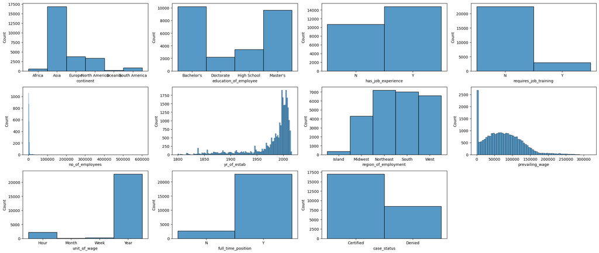

```python
plt.figure(figsize=(22, 12))
for _cont, _variable in enumerate(_data_copy.columns):
    plt.subplot(4, 4, _cont+1)
    sns.histplot(data=_data_copy, x=_variable)
    plt.tight_layout();
```

#### Observations

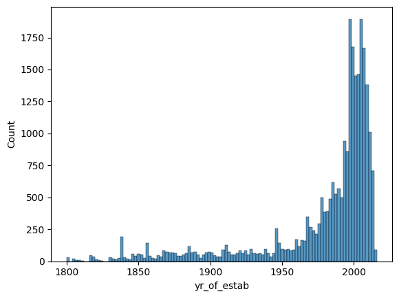

```python
sns.histplot(data=_data_copy, x='yr_of_estab');
```